# Self-Driving Car Engineer Nanodegree

## Project: Advanced Lane Lines Detection

**Author:** Bryan Rosales

**Date:** August 17 2017

My project includes the following files:

- P4.ipynb containing the script to process the images and lane line detection
- WriteUp P4.html which is this file reporting the project solution
- project_video.mp4 containing the video with the lane line detection and overlaping lane area

## Pipeline Description

1. Camera Calibration
2. Image distortion correction
3. Perspective Transformation
4. Binary Filtering and Lane Detection
5. Video Generation

## 1. Camera Calibration

To calibrate the camera I used the chessboard images provided by Udacity. Firstly, I set the objects points which will be the coordinates for each corner in the chess board. Secondly, I looked for the corners for each chess board image (9x6 corners) using cv2.findChessboardCorners(). Then, the function detected corners correctly in 17 images and 3 images were not detected the corners (9x6) correctly.

### Images with Corners Detected

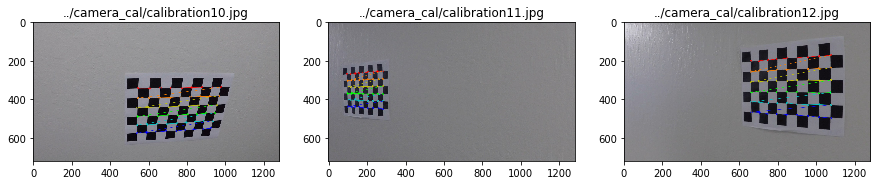

```python
displayImg(imgOk[0:3,:,:], labelOk[0:3], nImg=3, rows=1, cols=3, formatType='BGR', hFigure=20)
```

### Images that Corners were not Detected

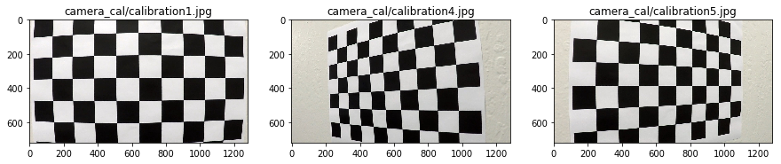

```python
displayImg(imgError[0:3,:,:], labelError[0:3], nImg=3, rows=1, cols=3, formatType='BGR', hFigure=10)
```

Once, I got the object and corners points, I called the function cv2.calibrateCamera to get the camera calibrated to the project. (cv2.calibrateCamera(objPoints, imgPoints, imgSize, None,None)).

## 2. Image distortion correction

In this stage, I used the camera matrix and the function cv2.undistort to get my images undistorted correcting the effect introduced by the camera lens.

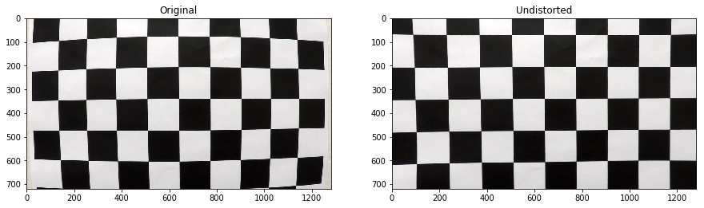

```python
displayImg(images, ulabels, nImg=2, rows=1, cols=2, formatType='BGR', hFigure=5)
```

Next, Since the camera is located in the front of the vehicle, I cropped the image 52 pixels in the bottom size to remove the car hook appearing in the image.

### Testing Images Undistorted

To demonstrate this step, I applied undistorting method in the test images and the following are the results.

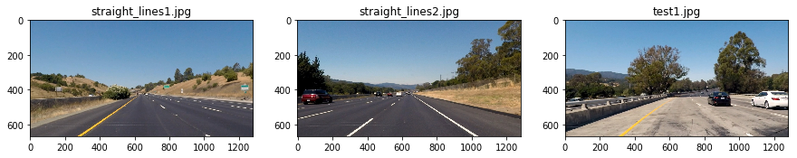

```python
displayImg(testImages[0:3], testLabels[0:3], nImg=3, rows=1, cols=3, formatType='BGR', hFigure=10)
```

## 3. Perspective Transformation

To this step, I selected 4 points in the undistorted image which are the reference points to transform the perspective. They are called source point or scr. Also, another 4 points referencing the destination space perspective were selected. Then, the source points were captured dierctly on the image using a image editor and fencing the lane lines interested area. For the destination points, I used a offset of 200 pixels to bring centered my lane lines in the transformed image.

This is the code defining the scr and dest points:

(h , w, c) = testImages[0].shape offset = 200

**Define the point for the Perspective Transformation** **topL, topR, botL, botR**

src = np.float32([[569, 460], [728, 460], [280, 667], [1030, 667]])

dst = np.float32([[0+offset,0+offset], [w-offset, 0+offset], [0+offset, h],[w-offset, h]])

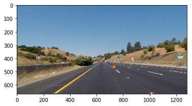

```python
plt.imshow(cv2.cvtColor(testImages[0], cv2.COLOR_BGR2RGB))
plt.plot(569,460,'*') #Top Left
plt.plot(728,460,'*') #Top Right
plt.plot(280,667,'*') #Bottom Left
plt.plot(1030,667,'*') #Bottom Right
```

Next, my script called the function imgPerspective to transform the perspective. Then, the function used the scr and dest points to calculate a transformation matrix and returned the image transformed.

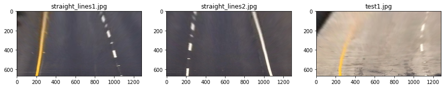

```python
displayImg(imgTransformed, testLabels, nImg=3, rows=1, cols=3, formatType='BGR', hFigure=10)
```

## 4. Binary Transformation and Lane Lines Detection

For binary filtering and transformation, I filtered yellow and white in a color map application to figure out the values in RGB color map of my lines color. Then, I created two function with the RGB values and filtered the image using such thresholds. Therefore, the result was two images with the pizels for yellow and white colors. Finally, I combined the two images using or operation pixel to pixel and generated a binary image.

The next is the code used to get an image to be processed.

```python
# CLAHE (Contrast Limited Adaptive Histogram Equalization)
def claheContrast(img):
    clahe = cv2.createCLAHE(clipLimit=2.0, tileGridSize=(8,8))
    return clahe.apply(img)

# Selection of Yellow and White Pixels
def select_yellow(image):
    lower = np.array([165,153,74])
    upper = np.array([255,214, 145])
    mask = cv2.inRange(image, lower, upper)
    # Bitwise-AND mask and original image
    res = cv2.bitwise_and(image,image, mask= mask)
    res = cv2.cvtColor(res, cv2.COLOR_BGR2GRAY)
    return res

def select_white(image):
    lower = np.array([202,202,202])
    upper = np.array([255,255,255])
    mask = cv2.inRange(image, lower, upper)
    # Bitwise-AND mask and original image
    res = cv2.bitwise_and(image,image, mask= mask)
    res = cv2.cvtColor(res, cv2.COLOR_BGR2GRAY)
    return res
```

```python
def binTransformation(img, cthresh=(160, 170)):

    whiteLine = select_white(img)
    yellowLine = select_yellow(img)
    cbinary = np.zeros_like(whiteLine)
    cbinary[(whiteLine > cthresh[0]) | (yellowLine > cthresh[1])] = 1

    return cbinary
```

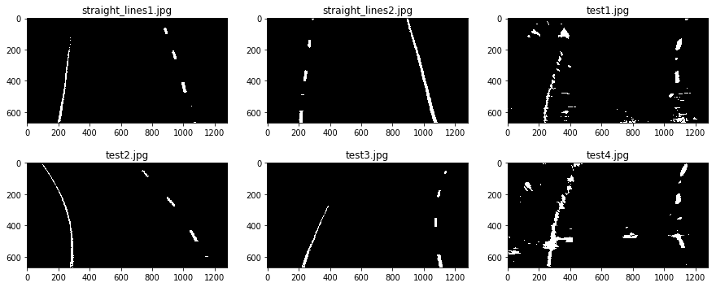

```python
displayImg(images, testLabels, nImg=6, rows=2, cols=3, formatType='', hFigure=6)
```

### Lane Lines Detection

In order to detect the lane lines in the binary image, a histogram of the image was neccesary. The highest frecuencies with 1's values showed the possible lane line. Therefore, my code extracted the bottom half part of the image and identified the peak to be set as a left and right bases to look for lane lines.

Next, I used 9 windows with 100 pixels margin to tracking each lane line from bottom to top using the of the points to recenter the window. Therefore, I got a collection of data points for each line (left and right) which I used to fit a polynomial degree 2 and draw every line.

fleft(y) = Ay^2 + By + c fright(y) = Ay^2 + By + c

left_fit = np.polyfit(lefty, leftx, 2) right_fit = np.polyfit(righty, rightx, 2)

Once I got a polynomial, I had not to run again the window process. Instead, for the next frame, I collected the points inside the margin and fitted a new polynomial degree 2 which represents the new points.

When the algorithm is not able to find the data point in the new frame, the window process restart.

### Histogram Sample Images

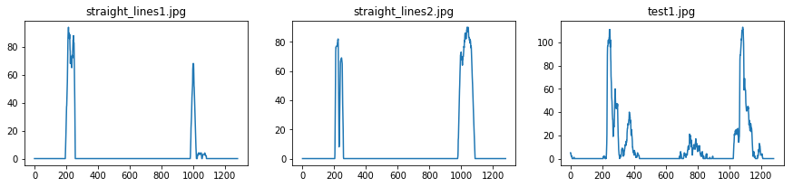

```python
displayImg(histogram, testLabels, nImg=3, rows=3, cols=3, formatType='HIST', hFigure=10)
```

### Detecting Data Points Sample Image

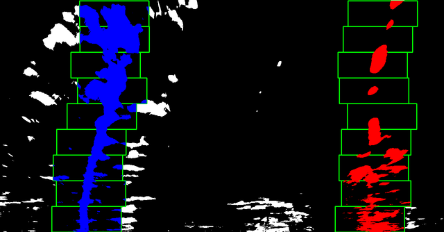

```python
Image(filename='w1.png')
```

### Interest Area inside Lane Lines

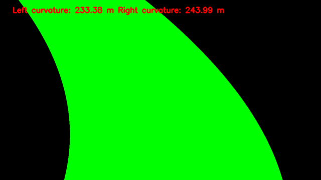

```python
Image(filename='c1.png')
```

### Radius of Curvature

if frames >= 10: ym_per_pix = 30/720 # meters per pixel in y dimension xm_per_pix = 3.7/700 # meters per pixel in x dimension

Next, I fitted a new polynomial in the x,y world space and calculated the radius of curvature formula.

**Fit new polynomials to x,y in world space**

```
left_fit_cr = np.polyfit(ploty*ym_per_pix, left_fitx*xm_per_pix, 2)
right_fit_cr = np.polyfit(ploty*ym_per_pix, right_fitx*xm_per_pix, 2)
```

**Calculate the new radius of curvature**

```
left_curverad = ((1 + (2*left_fit_cr[0]*y_eval*ym_per_pix + left_fit_cr[1])**2)**1.5) / np.absolute(2*left_fit_cr[0])
right_curverad = ((1 + (2*right_fit_cr[0]*y_eval*ym_per_pix + right_fit_cr[1])**2)**1.5) / np.absolute(2*right_fit_cr[0])
text1 = 'Left curvature: ' + str('{:04.2f}'.format(left_curverad)) + ' m ' + 'Right curvature: ' + str('{:04.2f}'.format(right_curverad)) + ' m'
```

### Center Lane Distance

To measure the distance of the center of the lane, I used the base point of each detected line and convert to meter units multiplying by the factor (3.7/700).

meter_lane_midpoint = (rightx_base + leftx_base) / 2 * (3.7/700)

Next, I calculated the center point of the image 1280 / 2 and convert to meter unit.

midpoint = np.int(hist.shape[0]/2) meter_image_midpoint = midpoint * (3.7/700)

Finally, the measurement is given by:

center_distance = abs(meter_image_midpoint-meter_lane_midpoint)

## 5. Video Generation

To read frame by frame from the project video, I am using VideoFileClip. Then, every frame read is passed to a pipeline function to execute all the steps described previously. Here is the summary of the steps:

```python
def pipeline(img):
    global text1
    (h , w, c) = img.shape

    # Define the point for the Perspective Inverse Transformation
    # topL, topR, botL, botR
    offset = 200
    src = np.float32([[569, 460], [728, 460], [280, 667], [1030, 667]])
    dst = np.float32([[0+offset,0+offset], [w-offset, 0+offset], [0+offset, h],[w-offset, h]])

    # Undistort the image read from the video
    img = imgUndistort(img, mtx, dist)

    # Change the Perspective or warp the image
    imgP = imgPerspective(img, src, dst, typeP='pnorm')

    # Create a Binary Image and applies Clahe and Thresholds
    imgB = binTransformation(imgP, cthresh=(195, 255))

    # Calculate the Histogram for the Bottom half image
    hist = histCalculation(imgB)

    # Generates a Polynomial degree 2 and Calculates the Curvature Radius
    imgOut = polynomialfit(imgB, hist)

    # Makes back or unwarp the image to the original perspective
    imgOut = imgPerspective(imgOut, src, dst, typeP='pinv')

    # Print the values for the curvature
    imgOut = cv2.putText(imgOut, text1,(50, 50), cv2.FONT_HERSHEY_SIMPLEX, 1.0, (0, 255, 0), 3)

    # Overlap the images
    imgOut = cv2.addWeighted(img, 1, imgOut, 0.3, 0)

    return imgOut
```

### Project Video Output

```python
from IPython.core.display import HTML
HTML("""
    <video controls src="{0}" loop=1 autoplay width=100%/>
    """.format('project_video.mp4')
)
```

[video not shown]

### Improvement in Resubmission

1. I improved the lines detection using threshold by color. I figured out the representation of yellow and white RGB which are the colors of my lines. Then, I applied a thershold to filter the most intensive pixels. Finally, I got a binary image applying a OR bitwise operation. The noise was reduced considerable but there are a couple segment of the lane where the algorithm loss the fitted polynomial because of the lacking of data points. However, the algorithm is able to recovery in the next frame.
2. The lane center distance was corrected. The formula had a error.
3. In order to improve the elimination of noise in the frame, the algorithm could be more smart to discard points that are outliers to the previous polynomial distribution. It might be set as a margin of the previous fitted polynomial.

So far, all the points annotated by the reviewer were corrected.